# Worked Example: Chile Plebiscite

Johan Larsson

## The 1988 Chilean Referendum

The [1988 Chilean national plebiscite](https://en.wikipedia.org/wiki/1988_Chilean_national_plebiscite) ended the reign of Chile’s then president (and former dictator) August Pinochet. Those in opposition to extend Pinochet’s rule for another eight years won with 56% of the vote. In this worked example we’ll try to probe the results of this plebiscite (referendum) by looking at a survey of voting intentions conducted a couple of months prior to the election.

The dataset is available in the carData package. Start by installing it (if you haven’t already).

```r
# install the carData package
install.packages("carData")
```

Then load the dataset directly into your workspace by calling the `data()` function as shown next.

```r
data("Chile", package = "carData")
```

There are eight variables in this dataset:

**`region`**

A factor with levels: C, Central; M, Metropolitan Santiago area; N, North; S, South; SA, city of Santiago.

**`population`**

population size of respondent’s community

**`sex`**

a factor with levels: F, female; M, male

**`age`**

age (in years)

**`education`**

a factor with levels (note: out of order): P, Primary; PS, Post-secondary; S, Secondary

**`income`**

monthly income (in Pesos)

**`statusquo`**

scale of support for the status quo

**`vote`**

a factor with levels: A, will abstain; N, will vote no (against Pinochet); U, undecided; Y, will vote yes (for Pinochet).

## Wrangling

Before we start visualizing this dataset, we need to format it properly. The names of the variables are fine, but the factor levels are hard to decipher. The `education` variable is also not coded as an ordinal variable although it should be. We save the new dataset in a new object called `Chile2`.

```r
library(tidyverse)

Chile2 <-
  Chile %>%
  as_tibble() %>%
  mutate(
    region = recode(
      region,
      "C" = "Central",
      "M" = "Metropolitan Santiago",
      "N" = "North",
      "S" = "South",
      "SA" = "City of Santiago"
    ),
    sex = recode(sex, "F" = "Women", "M" = "Men"),
    education = recode_factor(
      education,
      "P" = "Primary",
      "S" = "Secondary",
      "PS" = "Post-Secondary",
      .ordered = TRUE
    ),
    vote = recode(
      vote,
      "A" = "Abstain",
      "N" = "No",
      "U" = "Undecided",
      "Y" = "Yes"
    )
  )

Chile2
```

```
## # A tibble: 2,700 x 8
##    region population sex     age education      income statusquo vote
##    <fct>       <int> <fct> <int> <ord>           <int>     <dbl> <fct>
##  1 North      175000 Men      65 Primary         35000     1.01  Yes
##  2 North      175000 Men      29 Post-Secondary   7500    -1.30  No
##  3 North      175000 Women    38 Primary         15000     1.23  Yes
##  4 North      175000 Women    49 Primary         35000    -1.03  No
##  5 North      175000 Women    23 Secondary       35000    -1.10  No
##  6 North      175000 Women    28 Primary          7500    -1.05  No
##  7 North      175000 Men      26 Post-Secondary  35000    -0.786 No
##  8 North      175000 Women    24 Secondary       15000    -1.11  No
##  9 North      175000 Women    41 Primary         15000    -1.01  Undecided
## 10 North      175000 Men      41 Primary         15000    -1.30  No
## # … with 2,690 more rows
```

That looks much better.

Now let’s start by simply checking what the people in this survey actually intended to vote.

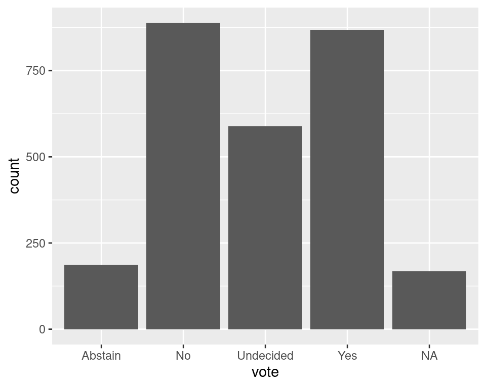

```r
ggplot(Chile2, aes(vote)) +
  geom_bar()
```

As we can see the referendum seem to be engaging much of the population under study. The no voters lead by a slim margin here, but there are many who are yet undecided.

## Age and Voting Intentions

Let’s try to see if we can flesh out these differences more in detail. We begin by studying age and voting intentions. Our first attempt is a proportional stacked density plot here, to focus on the proportions of voting intentions within each age group.

But before we do so, we will switch to a better default color palette for categorical (discrete) data, since the default palette in ggplot2 is really not quite ideal. A good choice could for instance be the “Accent” palette from RColorBrewer, but to spice it up we’ll go with a color palette inspired from The Darjeeling Limited by Wes Anderson that is available via the wesanderson package.[^1]

```r
# install.packages("wesanderson")
library(wesanderson)

darjeeling_pal <- function(...) {
  scale_fill_manual(...,
                    values = wes_palette("Darjeeling2"),
                    na.value = "grey")
}

# this option replaces the default palette for all future ggplots
options(ggplot2.discrete.fill = darjeeling_pal)
```

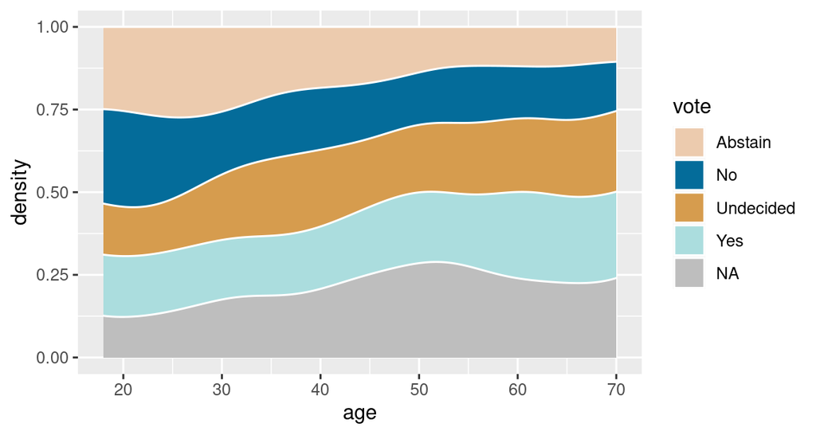

Voting intentions and age.

```r
ggplot(Chile2, aes(age, fill = vote)) +
  geom_density(position = "fill", col = "white")
```

This is probably quite fine as a comparison between the different voting categories, but does make it very hard to see the *actual* age distribution within each category. An alternative could be to use the ggridges package, which lets us plot shifted density plots.

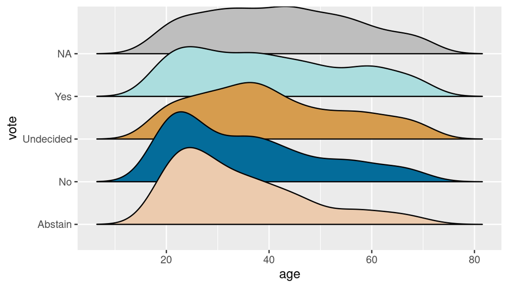

Distributions of age and voting intentions.

```r
# install.packages("ggridges")
library(ggridges)

ggplot(Chile2, aes(age, vote, fill = vote)) +
  geom_density_ridges2() +
  theme(legend.position = "none") # we don't need the legend here
```

All of the distributions are to some extent right-skewed[^2] The problem with this plot, however, is that it does not really answer the question that we’re interested in, which is to try to sift out to which degree various voter groups voted for the different options.

Taken together, it’s clear that those who are older are more prone to vote yes for another term form Pinochet, while no voters as well as people who intend to abstain are more frequent among the younger voters. One thing that is devious about these visualizations is that the missing data seems more prevalent from the plot types than is in fact the case. In the first plot, this happens because the `NA` values are relatively more frequent among the older ages and this part of the chart is enlarged in the proportional version of the chart due to fact that this age category is in minority. In the second, **ggridges** version, this happens simply because each geom shows the distribution within each category and all sum up to the same area.

## Age and Sex

We now continue to build our plot by introducing information on sex as well. The best way to do this is to use facets. When you are faceting on a single variable, you should mostly use `facet_wrap()` since it works better than `facet_grid()` when there are many levels.

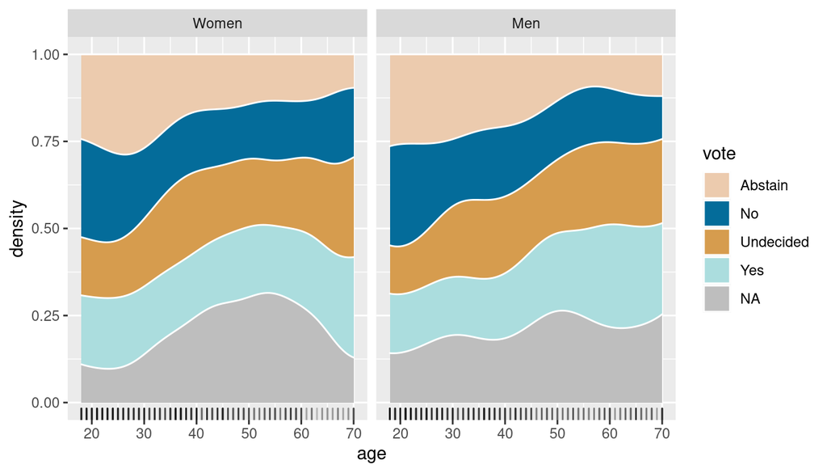

Voting intentions across the ages and sexes.

```r
ggplot(Chile2, aes(age, fill = vote)) +
  geom_density(position = "fill", col = "white") +
  geom_rug(alpha = 0.05) + # display marginal distribution
  facet_wrap("sex")
```

Looking at this plot, it seems like there are a few differences between men and women, for instance that more women then men seem poised to vote yes among the younger population.

We can take this even one step further, by involving our variables on education, income, or population. Let’s see if education matters.

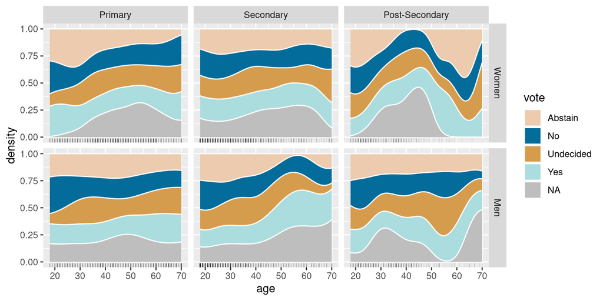

Voting intentions across age, sex, and educational attainment.

```r
Chile2 %>%
  drop_na(education) %>% # very small groups
  ggplot(aes(age, fill = vote)) +
  geom_density(position = "fill", col = "white") +
  geom_rug(alpha = 0.05) +
  facet_grid(sex ~ education)
```

One thing we really need to be very careful about is that we now have very little data in some regions of the plot, notably the older age groups that have post-secondary education (especially the women), which seem to be very few by considering the rug plot. For an even more clear demonstration of this, see the following plot where we’ve switched to a stacked non-proportional density plot.

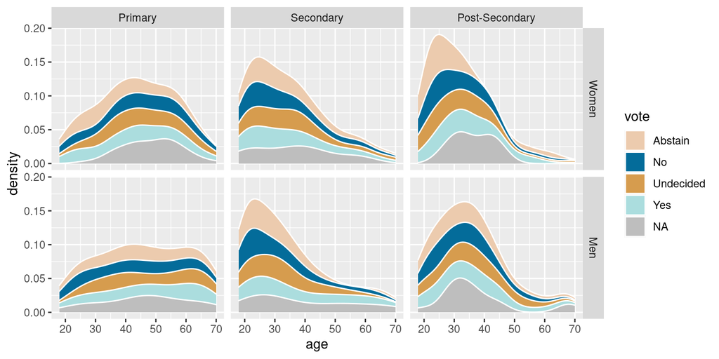

Voting intentions across age, sex, and educational attainment. A standard stacked density plot.

```r
Chile2 %>%
  drop_na(education) %>% # very small groups
  ggplot(aes(age, fill = vote)) +
  geom_density(position = "stack", col = "white") +
  facet_grid(sex ~ education)
```

This means that we should think again about our design. One possibility may be to cut age into age groups before plotting.

## Satisfaction with the Status Quo

The survey also included a question on satisfaction regarding the current state of affairs, which is recorded in the `statusquo` variable. Let’s take a look at this variable across age and region with a simple scatter plot.

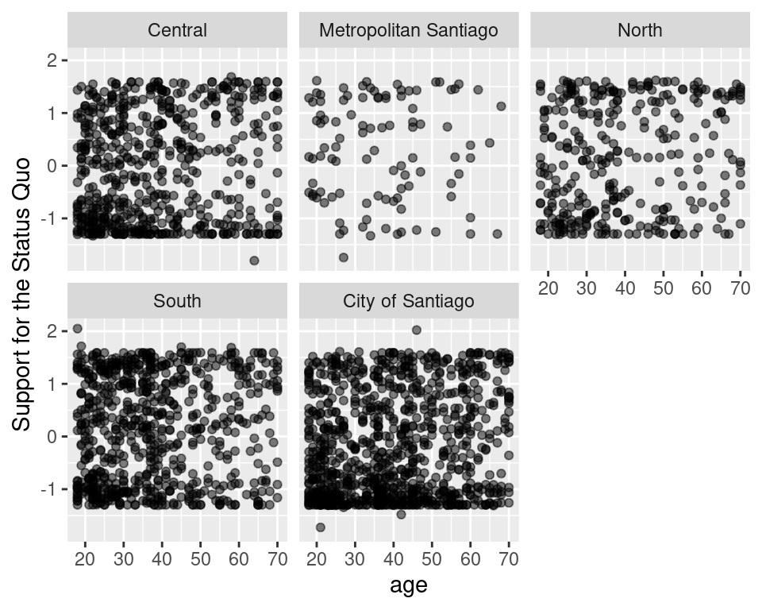

A simple (but unsuccessful) attempt to plot the satisfaction with the status quo in Chile against age and region.

```r
Chile2 %>%
  ggplot(aes(age, statusquo)) +
  geom_point(alpha = 0.5) +
  facet_wrap("region") +
  ylab("Support for the Status Quo")
```

The results are not attractive. There clearly appears to be some kind of relationship between age, location, and support for the status quo, but this plot fails to make those relationships clear, despite trying to mitigate some of the issues of overlapping with opacity.

Our next attempt is to try a hexagonal binning plot instead.

```r
Chile2 %>%
  ggplot(aes(age, statusquo)) +
  geom_hex(bins = 10) +
  facet_wrap("region") +
  ylab("Support for the Status Quo")
```

[figure not shown]

A hexagonal binning plot for the Chile survey data.

This certainly looks better. We now see that there appears to be a difference between the various regions and age groups. Support for the current regime seems to be weak in the City of Santiago, particularly for the younger age group.

One issue with using hexagon plots like this is that they put equal emphasis on both of the variables mapped to the x and y axes. When we are primarily interested in one of the variables—the support for the status quo here—this does not communicate this message effectively. To highlight the distribution of the status quo support, instead, it might therefore be more appropriate to use a different type of design.

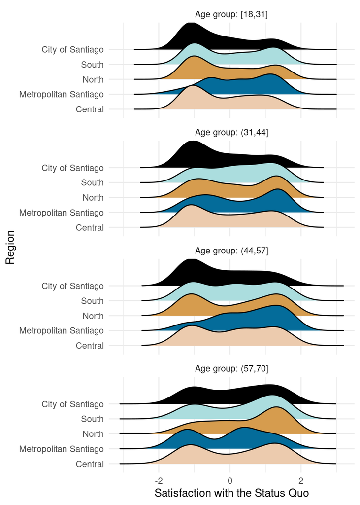

Gaussian density plots of satisfaction with the status quo in Chile in 1988 separated on age and region.

```r
Chile2 %>%
  drop_na(age) %>%
  mutate(`Age group` = cut_interval(age, 4)) %>%
  ggplot(aes(statusquo, region, fill = region)) +
  facet_wrap(~`Age group`, nrow = 4, labeller = label_both) +
  geom_density_ridges() +
  theme_minimal() +
  theme(legend.position = "none") +
  labs(y = "Region",
       x = "Satisfaction with the Status Quo")
```

The plot is now a piece of work that we should be happy with. Yes, we did lose some information when we cut the age variable into categories, but the final plot does a much better job of highlighting the goal of the visualization, which is to show satisfaction with the current government in Chile ahead of the upcoming plebiscite.

There remains some possible issues here. One is the use of density estimates here, which may not be appropriate for all of these categories, particularly not the *Metropolitan Santiago* region since it is small. An alternative could be to switch to histograms instead.[^3]

## Source Code

The source code for this document is available at https://github.com/stat-lu/STAE04/blob/master/worked-example-chile-plebiscite.Rmd.

[^1]: Feel free to replace the palette with your favorite Wes Anderson movie palette. How about Moonrise Kingdom?
[^2]: The nomenclature for skewness is confusing. When a distribution is said to be skewed to the right, it means that the *tail* is on the right side, even though it would probably make more sense to refer to the center of the distribution (and say that it was then left-skewed), but we need to stick to convention here. For more information, go to https://en.wikipedia.org/wiki/Skewness.
[^3]: See https://cran.r-project.org/web/packages/ggridges/vignettes/introduction.html for a guide on how to use histograms instead of density plots.